# EDA

##### Exploratory Analysis

This notebook contains an in depth overview of the dataset looking at:

- Individual features and their properties and distributions
- Basic relationships and correlation between individual features
- PCA and basic clustering of the dataset

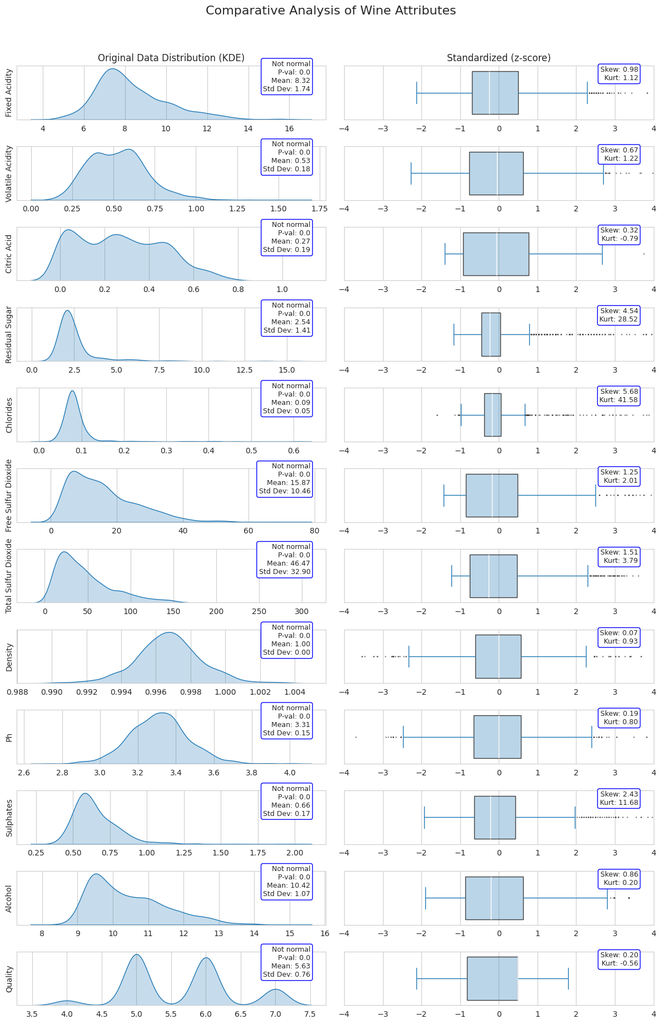

None of the variables are normally distributed.

Kurtosis how the tails of a distribution differ from the normal distribution. We can see that some variables:

- Residual Sugar
- Chlorides
- Sulphates have very high values. This indicates a high likelihood of outliers, as more data points are in the extremes of the distribution.

On the other hand features which have low kurtosis is closer to a normal distribution (with negative values indicatates less outlier than a normal distribution).

All the features are also skewed to the right to a smaller or bigger extent. It means that the bulk of the data for each feature concentrated on the lower end of the scale, with a tail that stretches towards higher values. Intuitively it makes sense e.g.:

- **Residual sugar**, most wines might have low sugar levels (dry wines), but a few wines (like desert wines) have very high sugar levels. This creates a long tail to the right while most data is clustered on the left (lower sugar levels). This is especially exacerbated by the fact that all the wines in the dataset come from the "Vinho Verde" region in Portugal were generally only dry wines are produced.
- Similar reasoning can be applied to **alcohol** content. Most wines might have a moderate alcohol level, but a few might have unusually high alcohol levels, again stretching the tail to the right.

#### Feature Analysis:

In this section we'll investigate individual features or feature pairs which might important for our future analysis.

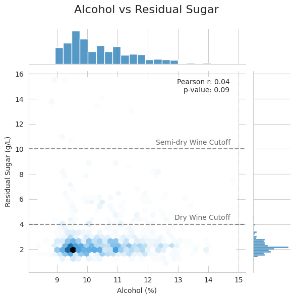

There seems to be no correlation between sugar and alcohol content which is something we would not expect if we were analyzing a broad selection of wines sampled globally. However, the dataset is restricted to wines from the 'Vinho Verde' region where sweet wines (as in most of Portugal) are not very popular, so it's not that surprising (sweet wines can have more than 30g\L of sugar and there are no such wines at all in the dataset).

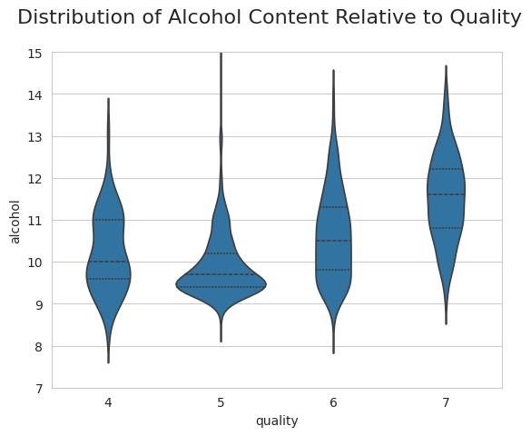

```
Kruskal-Wallis H Test (non-parametric version of ANOVA)
Statistic: 410.937, P-value: 0.00

Spearman's rank correlation
Statistic: 0.478, P-value: 0.00

Only Quality < 7:
Kruskal-Wallis statistic: 187.175, P-value: 0.00000
Spearman correlation: 0.335, P-value: 0.00

Only Quality < 6:
Kruskal-Wallis statistic: 8.312, P-value: 0.00394
Spearman correlation: -0.106, P-value: 0.00
```

There seems to be a significant statistical relationship between alcohol content and quality. However, it seems to be the strongest for high quality wines as the importance of alcohol for quality seems to decreases for lower quality wines. In fact between quality '4' and '5' the correlation is negative.

Generally relatively cheap wines for everyday consumption tend to be weaker. Based on the data we can see that while lower quality wines still might have a high alcohol content it's less likely that a weaker wines might have received a high quality score.

#### Correlations Between Other Features

Next we'll build a correlaiton matrix and try to look into what additional feature pairs it might be interesting to investigate:

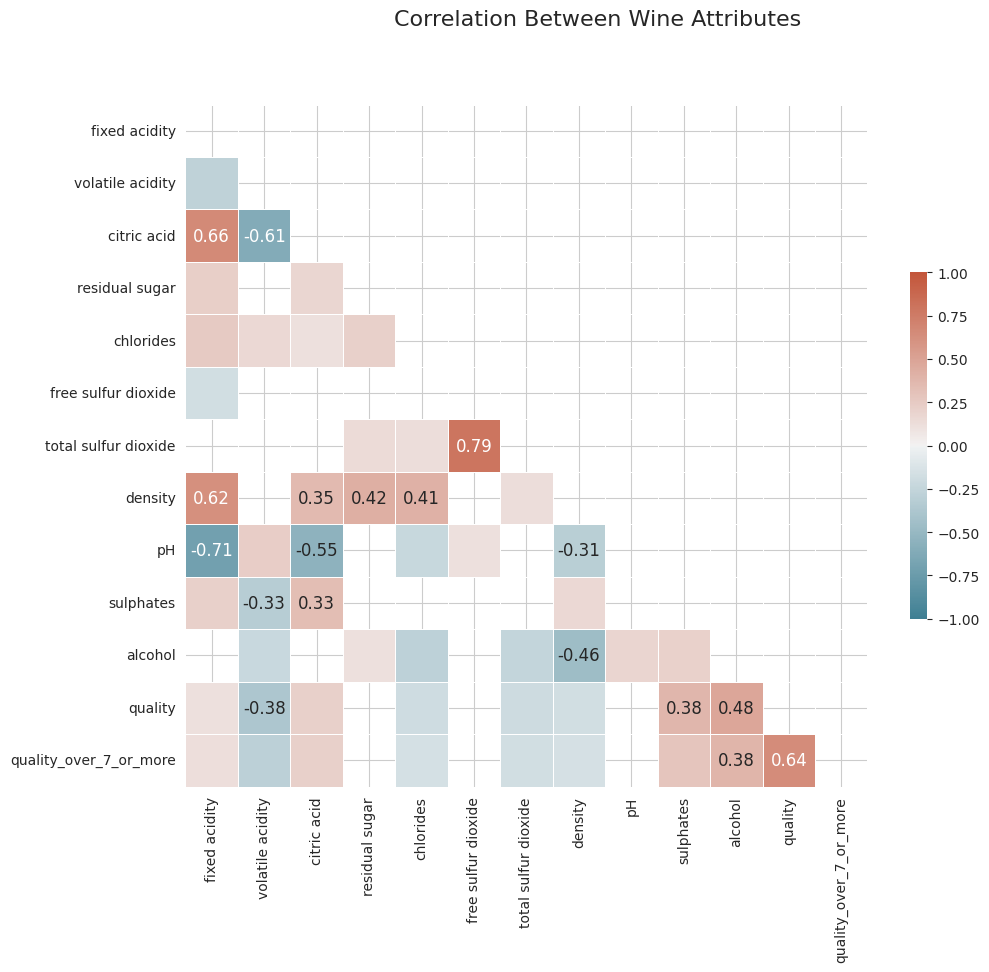

[output not shown]

[output cut: 20 more lines]

[output not shown]

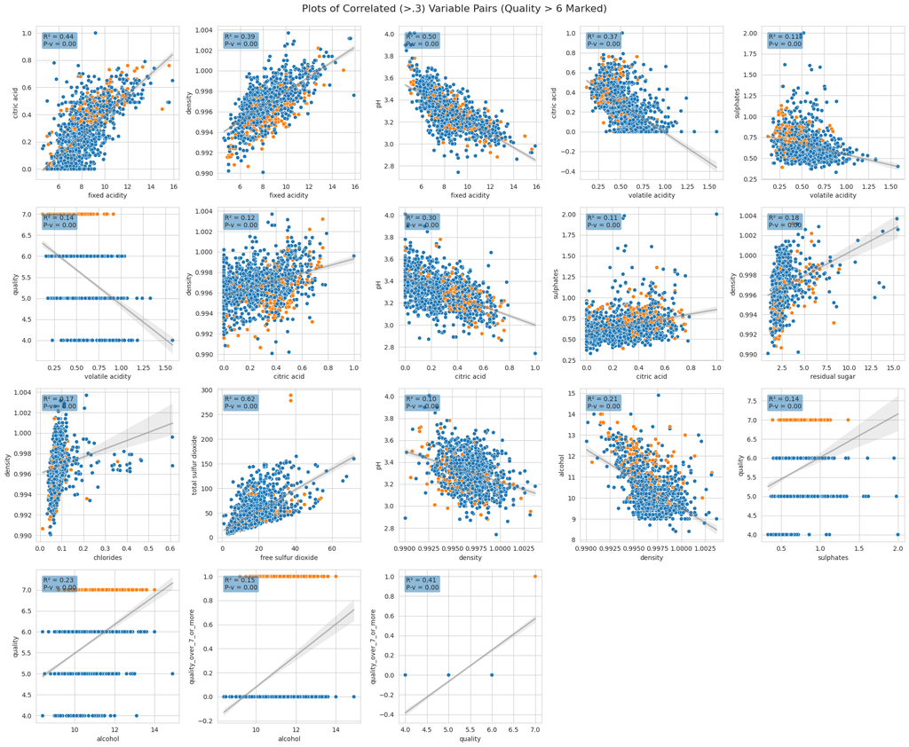

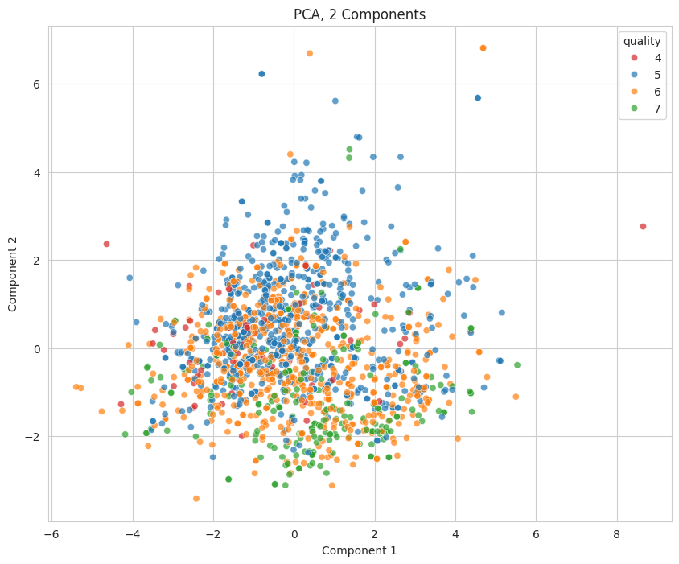

Because the variance explained by the first few components (e.g., PC1, PC2) remains constant as we increase the number of components, we can try and find the optimal level of components we might use in further analysis (balancing the total explained variance while keep the number of components as low as we can):

```
['PC1', 'PC2', 'PC3', 'PC4', 'PC5', 'PC6', 'PC7', 'PC8', 'PC9', 'PC10', 'PC11']
```

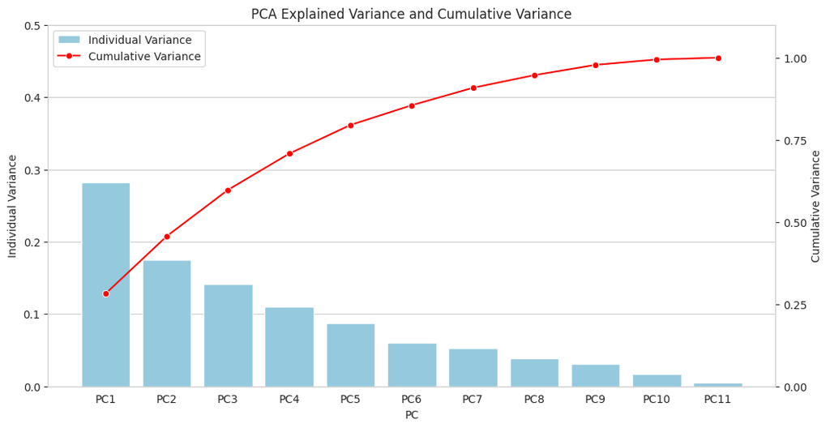

We can see that the proportion of variance explained by the first few components is somewhat low. PC1 explains 28% of variance, PC2 17% etc. We need at least 4 components to explain 70%.

This indicates that the dataset might have not strong underlying patterns and is strongly dispersed.

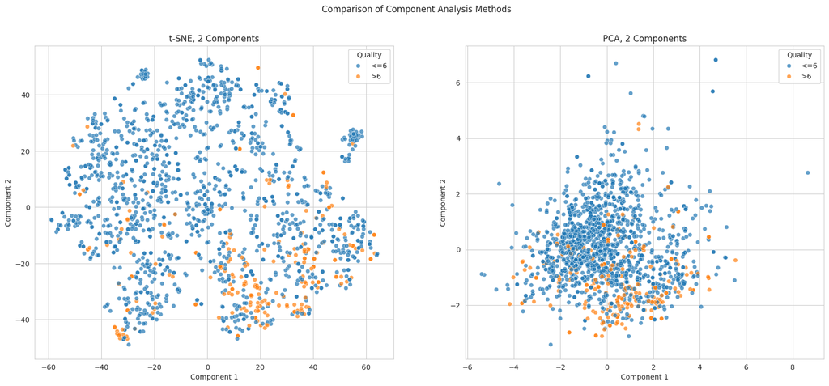

t-SNE groups data points based on how close they are to each other in the original high-dimensional space, forming clear clusters, it's a non-linear algorithm, which preserves local relationships and is better for visualizing clusters in high-dimensional data. **(PCA is a linear algorithm that reduces dimensionality by preserving maximum variance and feature correlation)**.

In theory we would expect that t-SNE would likely be more effective for visualizing clusters. Which we is something we'll try to do in our next step.

#### Clustering

If we were solving a real world problem, like for instance building a model/system which would allow wine merchants and distributors to select wines based on their chemical properties (to prioritize higher quality wines) in addition to finding identifying relationships between quality and other attributes (and building more complex models which we'll do in the 'Models' notebook we should consider another problem:

- A focus on quality alone may overlook consumer preferences for specific types of wine.

e.g. if it turns out that non-sweet, higher acidity wines with a high alcohol content tend to receive higher 'quality' only focusing on quality might not be the best approach. Consumers with a preference for these wines are likely to statisfied with us stocking just 2-3 brands of these wines. Meanwhile, those who prefer less acidic, lower alcohol wines would have limited choices.

Therefore, if a merchant uses our model or system to select a fixed number of wines, we should also aim to maximize the variety of that selection. To achieve this, we could cluster the dataset based on chemical properties. For example, if we find three distinct clusters in the dataset, a merchant wishing to order 15 new wines could choose 5 of the highest quality from each cluster. This approach avoids merely selecting the 15 wines expected to have the highest quality rating based on past data.

The **find_optimal_clusters** functions searchs for "best" candidate clusters using a weighted combined score of 'Silhouette', 'Calinski harabasz', 'Davies bouldin' metrics. Using a combination of clustering methods:

- Hierarchical
  - parameters: cutoff value
- DBSCAN
  - parameters: eps, min_samples

And a combination of prepreprocessing techniques:

- standardized data
- PCA (3..10 components)
- t-SNE (2 or 3 components)

While rejecting candidates where the smallest cluster has less than 100 items.

*Best Clusters:* Weights: Silhouette = 40% Calinski Harabasz = 20% Davies Bouldin = 20%

|  | name | component_method | n_components | method | cutoff | eps | min_samples | n_clusters | min_count_in_cluster | score_silhouette | score_calinski_harabasz | score_davies_bouldin | score |
| --- | --- | --- | --- | --- | --- | --- | --- | --- | --- | --- | --- | --- | --- |
| 24 | Hierarchical | PCA | 3.0 | ward | 40.0 | NaN | NaN | 5 | 123 | 0.253836 | 479.193982 | 1.088382 | 0.781727 |
| 23 | Hierarchical | PCA | 3.0 | ward | 38.0 | NaN | NaN | 5 | 123 | 0.253836 | 479.193982 | 1.088382 | 0.781727 |
| 22 | Hierarchical | PCA | 3.0 | ward | 36.0 | NaN | NaN | 5 | 123 | 0.253836 | 479.193982 | 1.088382 | 0.781727 |
| 21 | Hierarchical | PCA | 3.0 | ward | 34.0 | NaN | NaN | 5 | 123 | 0.253836 | 479.193982 | 1.088382 | 0.781727 |
| 27 | Hierarchical | PCA | 3.0 | ward | 46.0 | NaN | NaN | 3 | 259 | 0.272854 | 484.693746 | 1.342382 | 0.770490 |
| 26 | Hierarchical | PCA | 3.0 | ward | 44.0 | NaN | NaN | 3 | 259 | 0.272854 | 484.693746 | 1.342382 | 0.770490 |
| 28 | Hierarchical | PCA | 3.0 | ward | 48.0 | NaN | NaN | 3 | 259 | 0.272854 | 484.693746 | 1.342382 | 0.770490 |
| 29 | Hierarchical | PCA | 3.0 | ward | 50.0 | NaN | NaN | 3 | 259 | 0.272854 | 484.693746 | 1.342382 | 0.770490 |
| 25 | Hierarchical | PCA | 3.0 | ward | 42.0 | NaN | NaN | 4 | 141 | 0.257824 | 467.256782 | 1.248135 | 0.743775 |
| 54 | Hierarchical | PCA | 4.0 | ward | 54.0 | NaN | NaN | 3 | 491 | 0.228153 | 455.066384 | 1.450107 | 0.641516 |
| 55 | Hierarchical | PCA | 4.0 | ward | 56.0 | NaN | NaN | 3 | 491 | 0.228153 | 455.066384 | 1.450107 | 0.641516 |
| 53 | Hierarchical | PCA | 4.0 | ward | 52.0 | NaN | NaN | 3 | 491 | 0.228153 | 455.066384 | 1.450107 | 0.641516 |
| 52 | Hierarchical | PCA | 4.0 | ward | 50.0 | NaN | NaN | 3 | 491 | 0.228153 | 455.066384 | 1.450107 | 0.641516 |
| 51 | Hierarchical | PCA | 4.0 | ward | 48.0 | NaN | NaN | 3 | 491 | 0.228153 | 455.066384 | 1.450107 | 0.641516 |
| 20 | Hierarchical | PCA | 3.0 | ward | 32.0 | NaN | NaN | 6 | 123 | 0.194834 | 470.403046 | 1.230209 | 0.626559 |
| 78 | Hierarchical | PCA | 5.0 | ward | 50.0 | NaN | NaN | 4 | 302 | 0.196119 | 356.054636 | 1.439728 | 0.498312 |
| 77 | Hierarchical | PCA | 5.0 | ward | 48.0 | NaN | NaN | 4 | 302 | 0.196119 | 356.054636 | 1.439728 | 0.498312 |
| 76 | Hierarchical | PCA | 5.0 | ward | 46.0 | NaN | NaN | 4 | 302 | 0.196119 | 356.054636 | 1.439728 | 0.498312 |
| 79 | Hierarchical | PCA | 5.0 | ward | 52.0 | NaN | NaN | 3 | 302 | 0.202524 | 352.650037 | 1.519776 | 0.496877 |
| 80 | Hierarchical | PCA | 5.0 | ward | 54.0 | NaN | NaN | 3 | 302 | 0.202524 | 352.650037 | 1.519776 | 0.496877 |
| 100 | Hierarchical | PCA | 6.0 | ward | 48.0 | NaN | NaN | 4 | 343 | 0.173198 | 299.379109 | 1.587311 | 0.386788 |
| 101 | Hierarchical | PCA | 6.0 | ward | 50.0 | NaN | NaN | 4 | 343 | 0.173198 | 299.379109 | 1.587311 | 0.386788 |
| 102 | Hierarchical | PCA | 6.0 | ward | 52.0 | NaN | NaN | 4 | 343 | 0.173198 | 299.379109 | 1.587311 | 0.386788 |
| 146 | Hierarchical | PCA | 8.0 | ward | 50.0 | NaN | NaN | 3 | 407 | 0.177046 | 296.420011 | 1.843917 | 0.365125 |
| 147 | Hierarchical | PCA | 8.0 | ward | 52.0 | NaN | NaN | 3 | 407 | 0.177046 | 296.420011 | 1.843917 | 0.365125 |
| 148 | Hierarchical | PCA | 8.0 | ward | 54.0 | NaN | NaN | 3 | 407 | 0.177046 | 296.420011 | 1.843917 | 0.365125 |
| 149 | Hierarchical | PCA | 8.0 | ward | 56.0 | NaN | NaN | 3 | 407 | 0.177046 | 296.420011 | 1.843917 | 0.365125 |
| 124 | Hierarchical | PCA | 7.0 | ward | 52.0 | NaN | NaN | 3 | 333 | 0.170485 | 287.580225 | 1.817018 | 0.347405 |
| 123 | Hierarchical | PCA | 7.0 | ward | 50.0 | NaN | NaN | 4 | 324 | 0.162767 | 282.191413 | 1.653920 | 0.344385 |
| 122 | Hierarchical | PCA | 7.0 | ward | 48.0 | NaN | NaN | 4 | 324 | 0.162767 | 282.191413 | 1.653920 | 0.344385 |
| 103 | Hierarchical | PCA | 6.0 | ward | 54.0 | NaN | NaN | 3 | 343 | 0.160272 | 294.946533 | 1.769358 | 0.338022 |
| 192 | Hierarchical | PCA | 10.0 | ward | 50.0 | NaN | NaN | 3 | 281 | 0.158400 | 264.411963 | 1.855681 | 0.301052 |
| 193 | Hierarchical | PCA | 10.0 | ward | 52.0 | NaN | NaN | 3 | 281 | 0.158400 | 264.411963 | 1.855681 | 0.301052 |
| 194 | Hierarchical | PCA | 10.0 | ward | 54.0 | NaN | NaN | 3 | 281 | 0.158400 | 264.411963 | 1.855681 | 0.301052 |
| 0 | Hierarchical | None | NaN | ward | 52.0 | NaN | NaN | 3 | 485 | 0.157747 | 265.069859 | 1.973112 | 0.290532 |
| 1 | Hierarchical | None | NaN | ward | 54.0 | NaN | NaN | 3 | 485 | 0.157747 | 265.069859 | 1.973112 | 0.290532 |
| 4 | Hierarchical | None | NaN | ward | 60.0 | NaN | NaN | 3 | 485 | 0.157747 | 265.069859 | 1.973112 | 0.290532 |
| 3 | Hierarchical | None | NaN | ward | 58.0 | NaN | NaN | 3 | 485 | 0.157747 | 265.069859 | 1.973112 | 0.290532 |
| 2 | Hierarchical | None | NaN | ward | 56.0 | NaN | NaN | 3 | 485 | 0.157747 | 265.069859 | 1.973112 | 0.290532 |
| 171 | Hierarchical | PCA | 9.0 | ward | 54.0 | NaN | NaN | 3 | 511 | 0.142986 | 270.050435 | 1.997016 | 0.263892 |
| 170 | Hierarchical | PCA | 9.0 | ward | 52.0 | NaN | NaN | 3 | 511 | 0.142986 | 270.050435 | 1.997016 | 0.263892 |
| 169 | Hierarchical | PCA | 9.0 | ward | 50.0 | NaN | NaN | 3 | 511 | 0.142986 | 270.050435 | 1.997016 | 0.263892 |

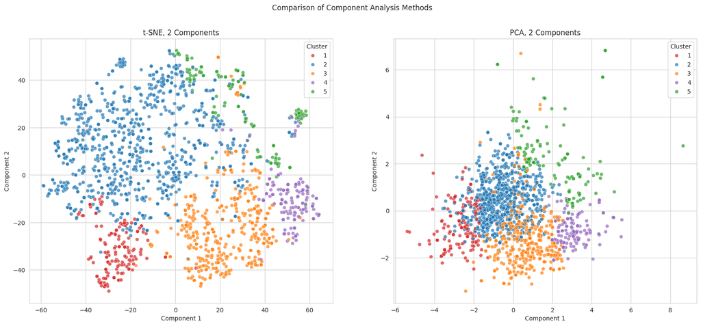

Cluster 2

- n: 832 *These wines are characterized by a slightly lower citric acid and alcohol content, offering a subtly smoother and lighter taste profile*

```
- Citric Acid:
  P-val: 0.0 < 0.05 (u_stat=473642)
  mean: 0.1723 (-0.0987 | z=-0.51 | Cohen's d*=-0.56)
  median: 0.1600
  Q1: 0.0500 (-0.0400 | z=-0.21)
  Q3: 0.2600 (-0.1600 | z=-0.82)

- Alcohol:
  P-val: 0.0 < 0.05 (u_stat=495266)
  mean: 9.9128 (-0.5102 | z=-0.48 | Cohen's d*=-0.55)
  median: 9.8000
  Q1: 9.5000 (+0.0000 | z=+0.00)
  Q3: 10.3000 (-0.8000 | z=-0.75)
```

Cluster 3

- n: 367 *This selection stands out for its notably lower volatile acidity and higher citric acid and alcohol levels, providing a robust flavor with a distinctive sharpness*

```
- Volatile Acidity:
  P-val: 0.0 < 0.05 (u_stat=114673)
  mean: 0.3527 (-0.1751 | z=-0.98 | Cohen's d*=-1.05)
  median: 0.3500
  Q1: 0.2900 (-0.1000 | z=-0.56)
  Q3: 0.4100 (-0.2300 | z=-1.28)

- Citric Acid:
  P-val: 0.0 < 0.05 (u_stat=434722)
  mean: 0.4251 (+0.1541 | z=+0.79 | Cohen's d*=+0.85)
  median: 0.4200
  Q1: 0.3450 (+0.2550 | z=+1.31)
  Q3: 0.4900 (+0.0700 | z=+0.36)

- Alcohol:
  P-val: 0.0 < 0.05 (u_stat=440834)
  mean: 11.3275 (+0.9045 | z=+0.85 | Cohen's d*=+0.87)
  median: 11.3000
  Q1: 10.8000 (+1.3000 | z=+1.22)
  Q3: 12.0000 (+0.9000 | z=+0.84)

- Quality:
  P-val: 0.0 < 0.05 (u_stat=403496)
  mean: 6.1744 (+0.5434 | z=+0.71 | Cohen's d*=+0.72)
  median: 6.0000
  Q1: 6.0000 (+1.0000 | z=+1.31)
  Q3: 7.0000 (+1.0000 | z=+1.31)
```

Cluster 5

- n: 123 *Wines in this cluster are distinguished by their higher residual sugar and chloride content, offering a sweeter, more pronounced taste with a hint of saltiness*

```
- Citric Acid:
  P-val: 0.0 < 0.05 (u_stat=133240)
  mean: 0.3939 (+0.1229 | z=+0.63 | Cohen's d*=+0.63)
  median: 0.3700
  Q1: 0.2600 (+0.1700 | z=+0.87)
  Q3: 0.5100 (+0.0900 | z=+0.46)

- Residual Sugar:
  P-val: 0.0 < 0.05 (u_stat=136510)
  mean: 4.1467 (+1.6079 | z=+1.14 | Cohen's d*=+1.00)
  median: 2.8000
  Q1: 2.1000 (+0.2000 | z=+0.14)
  Q3: 4.8500 (+2.2500 | z=+1.60)

- Chlorides:
  P-val: 0.0 < 0.05 (u_stat=143542)
  mean: 0.1491 (+0.0616 | z=+1.31 | Cohen's d*=+1.10)
  median: 0.0970
  Q1: 0.0805 (+0.0105 | z=+0.22)
  Q3: 0.1235 (+0.0335 | z=+0.71)

- Free Sulfur Dioxide:
  P-val: 0.0 < 0.05 (u_stat=158324)
  mean: 28.4309 (+12.5560 | z=+1.20 | Cohen's d*=+1.19)
  median: 27.0000
  Q1: 20.0000 (+13.0000 | z=+1.24)
  Q3: 34.0000 (+13.0000 | z=+1.24)

- Total Sulfur Dioxide:
  P-val: 0.0 < 0.05 (u_stat=168335)
  mean: 95.1301 (+48.6623 | z=+1.48 | Cohen's d*=+1.48)
  median: 95.0000
  Q1: 67.0000 (+45.0000 | z=+1.37)
  Q3: 122.0000 (+60.0000 | z=+1.82)

- Density:
  P-val: 0.0 < 0.05 (u_stat=154739)
  mean: 0.9986 (+0.0019 | z=+1.01 | Cohen's d*=+1.01)
  median: 0.9982
  Q1: 0.9976 (+0.0020 | z=+1.06)
```

[output cut: 14 more lines]

```
  Q3: 0.9950 (+0.2650 | z=+1.56)

- Alcohol:
  P-val: 0.0 < 0.05 (u_stat=48006)
  mean: 9.6081 (-0.8149 | z=-0.76 | Cohen's d*=-0.78)
  median: 9.4000
  Q1: 9.2500 (-0.2500 | z=-0.23)
  Q3: 9.8000 (-1.3000 | z=-1.22)

- Quality:
  P-val: 0.0 < 0.05 (u_stat=69350)
  mean: 5.2439 (-0.3871 | z=-0.51 | Cohen's d*=-0.52)
  median: 5.0000
  Q1: 5.0000 (+0.0000 | z=+0.00)
  Q3: 5.0000 (-1.0000 | z=-1.31)
```

Cluster 1

- n: 141 *Featuring a lower level of fixed acidity and citric acid, these wines are milder and less acidic, ideal for those who enjoy a softer palate*

```
- Fixed Acidity:
  P-val: 0.0 < 0.05 (u_stat=24528)
  mean: 6.2340 (-2.0856 | z=-1.20 | Cohen's d*=-1.24)
  median: 6.2000
  Q1: 5.6000 (-1.5000 | z=-0.86)
  Q3: 6.7000 (-2.5000 | z=-1.44)

- Citric Acid:
  P-val: 0.0 < 0.05 (u_stat=44760)
  mean: 0.0771 (-0.1939 | z=-1.00 | Cohen's d*=-1.03)
  median: 0.0400
  Q1: 0.0000 (-0.0900 | z=-0.46)
  Q3: 0.1100 (-0.3100 | z=-1.59)

- Density:
  P-val: 0.0 < 0.05 (u_stat=21792)
  mean: 0.9939 (-0.0028 | z=-1.51 | Cohen's d*=-1.54)
  median: 0.9940
  Q1: 0.9932 (-0.0024 | z=-1.27)
  Q3: 0.9950 (-0.0028 | z=-1.50)

- Ph:
  P-val: 0.0 < 0.05 (u_stat=192439)
  mean: 3.5210 (+0.2099 | z=+1.36 | Cohen's d*=+1.37)
  median: 3.5100
  Q1: 3.4200 (+0.2100 | z=+1.36)
  Q3: 3.5800 (+0.1800 | z=+1.17)

- Alcohol:
  P-val: 0.0 < 0.05 (u_stat=192422)
  mean: 11.9104 (+1.4874 | z=+1.40 | Cohen's d*=+1.41)
  median: 11.7000
  Q1: 11.3000 (+1.8000 | z=+1.69)
  Q3: 12.6000 (+1.5000 | z=+1.41)
```

Cluster 4

- n: 136 *This group is unique for its significantly higher fixed acidity and density, resulting in wines that are more full-bodied and intense*

```
- Fixed Acidity:
  P-val: 0.0 < 0.05 (u_stat=203405)
  mean: 11.8941 (+3.5745 | z=+2.05 | Cohen's d*=+2.08)
  median: 11.8500
  Q1: 11.1000 (+4.0000 | z=+2.30)
  Q3: 12.6250 (+3.4250 | z=+1.97)

- Volatile Acidity:
  P-val: 0.0 < 0.05 (u_stat=76024)
  mean: 0.4383 (-0.0895 | z=-0.50 | Cohen's d*=-0.51)
  median: 0.4125
  Q1: 0.3500 (-0.0400 | z=-0.22)
  Q3: 0.5300 (-0.1100 | z=-0.61)

- Citric Acid:
  P-val: 0.0 < 0.05 (u_stat=192035)
  mean: 0.5485 (+0.2776 | z=+1.42 | Cohen's d*=+1.47)
  median: 0.5200
  Q1: 0.4900 (+0.4000 | z=+2.05)
  Q3: 0.6300 (+0.2100 | z=+1.08)

- Free Sulfur Dioxide:
  P-val: 0.0 < 0.05 (u_stat=58602)
  mean: 8.5588 (-7.3161 | z=-0.70 | Cohen's d*=-0.72)
  median: 6.0000
  Q1: 5.7500 (-1.2500 | z=-0.12)
  Q3: 10.0000 (-11.0000 | z=-1.05)

- Total Sulfur Dioxide:
  P-val: 0.0 < 0.05 (u_stat=70260)
  mean: 27.3088 (-19.1590 | z=-0.58 | Cohen's d*=-0.60)
  median: 23.5000
  Q1: 17.7500 (-4.2500 | z=-0.13)
  Q3: 35.0000 (-27.0000 | z=-0.82)

- Density:
  P-val: 0.0 < 0.05 (u_stat=193708)
  mean: 0.9995 (+0.0027 | z=+1.46 | Cohen's d*=+1.48)
  median: 0.9994
  Q1: 0.9986 (+0.0030 | z=+1.59)
  Q3: 1.0002 (+0.0024 | z=+1.25)

- Ph:
  P-val: 0.0 < 0.05 (u_stat=30996)
  mean: 3.1152 (-0.1959 | z=-1.27 | Cohen's d*=-1.30)
  median: 3.1100
  Q1: 3.0500 (-0.1600 | z=-1.04)
  Q3: 3.1900 (-0.2100 | z=-1.36)
```

* Cohen's d measures the effect size between two groups using the pooled standard deviation, a combined measure of both groups' variability. Unlike the Z-Score, which compares individual scores to a group average, Cohen's d is better for comparing two distinct groups because it specifically addresses their relative difference in the context of their combined variability

```
DBSCAN Silhouette Score with eps=0.5: -0.20350272309100015
DBSCAN Silhouette Score with eps=1: -0.34493001193186973
DBSCAN Silhouette Score with eps=2: 0.040976239431270094
DBSCAN Silhouette Score with eps=3: 0.4821700727716611
DBSCAN Silhouette Score with eps=4: 0.5822281107253913
DBSCAN Silhouette Score with eps=5: 0.60652848925529
DBSCAN Silhouette Score with eps=6: 0.7014368933775703
```

Attempts to cluster the data have been complicated.

This indicates that performing clustering on data processed with PCA might be more beneficial.